# Klamath Basin Flow Gage EDA

## Main stream Klamath

- 11509500 - Klamath River at Keno Or
- 11510700 - Klamath River Below John C Boyle Powerplant
- 11516530 - Klamath River Below Iorngate Dam
- 11520500 - Klamath River Nr Seiad Valley CA
- 11523000 - Klamath River A Orleans
- 11530500 - Klamath River Near Klamath (Furthest Downstream)

```r
kr_at_keno_or <- dataRetrieval::readNWISdv(11509500, "00060", startDate = "1950-01-01") |>
  select(date = Date, value =  X_00060_00003) |>  # rename to value
  as_tibble() |>
  mutate(stream = "klamath river", # add additional columns for stream, gage info, and parameter
         order = 1,
         gage_agency = "USGS",
         gage_number = "11509500",
         parameter = "flow",
         statistic = "mean", # if query returns instantaneous data then report a min, mean, and max
         latitude = dataRetrieval::readNWISsite("11509500")$dec_lat_va, # directly add lat
         longitude = dataRetrieval::readNWISsite("11509500")$dec_long_va # directly add lon
         )
kr_blw_powerplant <- dataRetrieval::readNWISdv(11510700, "00060", startDate = "1995-01-01") |>
  select(date = Date, value =  X_00060_00003) |>  # rename to value
  as_tibble() |>
  mutate(stream = "klamath river", # add additional columns for stream, gage info, and parameter
         order = 2,
         gage_agency = "USGS",
         gage_number = "11510700",
         parameter = "flow",
         statistic = "mean", # if query returns instantaneous data then report a min, mean, and max
                  latitude = dataRetrieval::readNWISsite("11510700")$dec_lat_va, # directly add lat
         longitude = dataRetrieval::readNWISsite("11510700")$dec_long_va # directly add lon
         )
kr_blw_iorngage <- dataRetrieval::readNWISdv(11516530, "00060", startDate = "1950-01-01") |>
  select(date = Date, value =  X_00060_00003) |>  # rename to value
  as_tibble() |>
  mutate(stream = "klamath river", # add additional columns for stream, gage info, and parameter
         order = 3,
         gage_agency = "USGS",
         gage_number = "11516530",
         parameter = "flow",
         statistic = "mean", # if query returns instantaneous data then report a min, mean, and max
         latitude = dataRetrieval::readNWISsite("11516530")$dec_lat_va, # directly add lat
         longitude = dataRetrieval::readNWISsite("11516530")$dec_long_va # directly add lon
         )
kr_nr_seiad_valley <- dataRetrieval::readNWISdv(11520500, "00060", startDate = "1950-01-01") |>
  select(date = Date, value =  X_00060_00003) |>  # rename to value
  as_tibble() |>
  mutate(stream = "klamath river", # add additional columns for stream, gage info, and parameter
         order = 4,
         gage_agency = "USGS",
         gage_number = "11520500",
         parameter = "flow",
         statistic = "mean", # if query returns instantaneous data then report a min, mean, and max
         latitude = dataRetrieval::readNWISsite("11520500")$dec_lat_va, # directly add lat
         longitude = dataRetrieval::readNWISsite("11520500")$dec_long_va # directly add lon
         )
kr_at_orleans <- dataRetrieval::readNWISdv(11523000, "00060", startDate = "1950-01-01") |>
  select(date = Date, value =  X_00060_00003) |>  # rename to value
  as_tibble() |>
  mutate(stream = "klamath river", # add additional columns for stream, gage info, and parameter
         order = 5,
         gage_agency = "USGS",
         gage_number = "11523000",
         parameter = "flow",
         statistic = "mean", # if query returns instantaneous data then report a min, mean, and max
         latitude = dataRetrieval::readNWISsite("11523000")$dec_lat_va, # directly add lat
         longitude = dataRetrieval::readNWISsite("11523000")$dec_long_va # directly add lon
         )
kr_nr_klamath <- dataRetrieval::readNWISdv(11530500, "00060", startDate = "1950-01-01") |>
  select(date = Date, value =  X_00060_00003) |>  # rename to value
  as_tibble() |>
  mutate(stream = "klamath river", # add additional columns for stream, gage info, and parameter
         order = 6,
         gage_agency = "USGS",
         gage_number = "11530500",
         parameter = "flow",
         statistic = "mean", # if query returns instantaneous data then report a min, mean, and max
         latitude = dataRetrieval::readNWISsite("11530500")$dec_lat_va, # directly add lat
         longitude = dataRetrieval::readNWISsite("11530500")$dec_long_va # directly add lon
         )

all_kalamth_usgs_gages <- bind_rows(kr_at_keno_or, kr_blw_powerplant, kr_blw_iorngage, kr_nr_seiad_valley,
                                    kr_at_orleans, kr_nr_klamath) |>
  glimpse()
```

```
#> Rows: 141,866
#> Columns: 10
#> $ date        <date> 1950-01-01, 1950-01-02, 1950-01-03, 1950-01-04, 1950-01-0…
#> $ value       <dbl> 1580, 1470, 1500, 1500, 1430, 1270, 1090, 1170, 1350, 1510…
#> $ stream      <chr> "klamath river", "klamath river", "klamath river", "klamat…
#> $ order       <dbl> 1, 1, 1, 1, 1, 1, 1, 1, 1, 1, 1, 1, 1, 1, 1, 1, 1, 1, 1, 1…
#> $ gage_agency <chr> "USGS", "USGS", "USGS", "USGS", "USGS", "USGS", "USGS", "U…
#> $ gage_number <chr> "11509500", "11509500", "11509500", "11509500", "11509500"…
#> $ parameter   <chr> "flow", "flow", "flow", "flow", "flow", "flow", "flow", "f…
#> $ statistic   <chr> "mean", "mean", "mean", "mean", "mean", "mean", "mean", "m…
#> $ latitude    <dbl> 42.1332, 42.1332, 42.1332, 42.1332, 42.1332, 42.1332, 42.1…
#> $ longitude   <dbl> -121.9622, -121.9622, -121.9622, -121.9622, -121.9622, -12…
```

### Map Plot Klamath USGS Gages

```r
# Filter to keep only one unique gage per location
klmath_gage_dates <- all_kalamth_usgs_gages |>
  group_by(gage_number) |>
  summarise(min_date = min(date), max_date = max(date))

unique_gage_data_kl <- all_kalamth_usgs_gages |>
  distinct(gage_number, latitude, longitude, .keep_all = TRUE) |>
  left_join(klmath_gage_dates, by = "gage_number")

unique_gage_sf <- unique_gage_data_kl |>
  st_as_sf(coords = c("longitude", "latitude"), crs = 4326)

leaflet(unique_gage_sf) |>
  addTiles() |>
  addCircleMarkers(popup = ~paste0("Stream name: ", stream, "<br>Gage Number: ", gage_number, "<br>Max Date: ", max_date, "<br>Min Date: ", min_date))
```

[interactive chart not shown]

### Date coverage

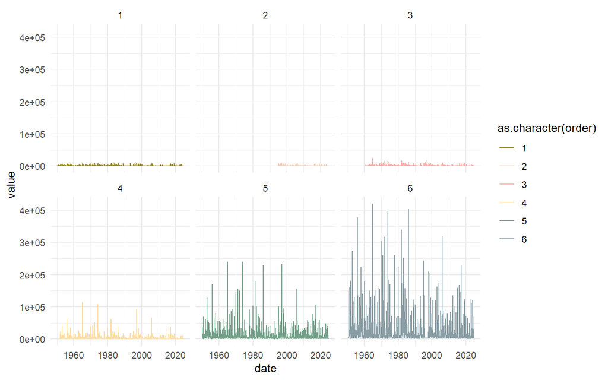

```r
all_kalamth_usgs_gages |> ggplot(aes(x = date, y = value, color = as.character(order))) +
  geom_line() +
  scale_color_manual(values = colors_full) +
  facet_wrap(~order) +
  theme_minimal()
```

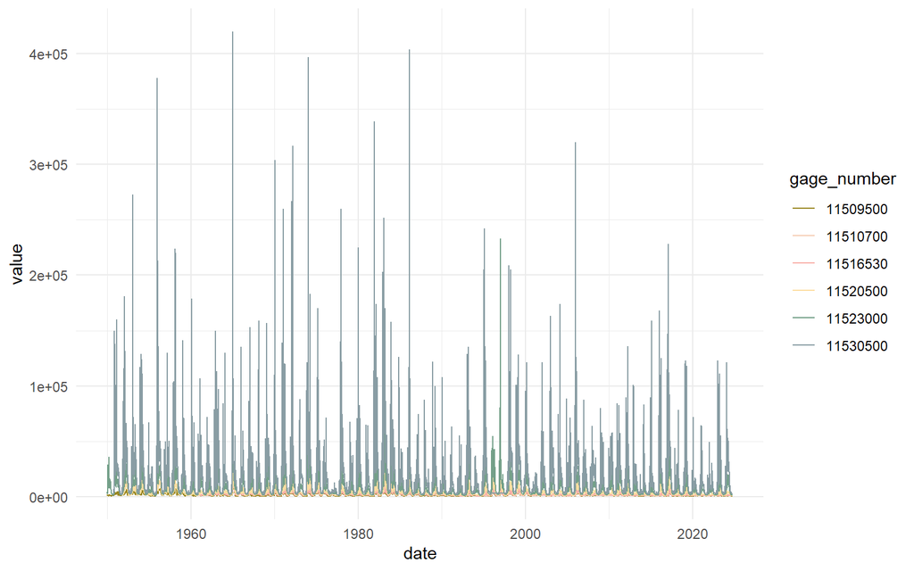

```r
all_kalamth_usgs_gages |>
  ggplot(aes(x = date, y = value, color = gage_number)) +
  geom_line() +
  scale_color_manual(values = colors_full) +
  theme_minimal()
```

### Date range summary

```
#> Rows: 6
#> Columns: 4
#> $ gage_number  <chr> "11509500", "11510700", "11516530", "11520500", "11523000…
#> $ min_date     <date> 1950-01-01, 1995-01-01, 1960-10-01, 1951-10-01, 1950-01-…
#> $ max_date     <date> 2024-10-06, 2024-10-06, 2024-10-06, 2024-10-06, 2024-10-…
#> $ record_count <int> 27308, 10872, 23382, 26670, 27308, 26326
```

## Trinity

Potential gages

- 11528700 SF TRINITY R BL HYAMPOM CA - South fork
- 11530000 TRINITY R A HOOPA CA
- 11523200 TRINITY R AB COFFEE C NR TRINITY CENTER CA
- 11525500 TRINITY R A LEWISTON CA
- 11525655 TRINITY R BL LIMEKILN GULCH NR DOUGLAS CITY CA
- 11525854 TRINITY R A DOUGLAS CITY CA
- 11526250 TRINITY R A JUNCTION CITY CA
- 11526400 TRINITY R AB NF TRINITY R NR HELENA CA
- 11527000 TRINITY R NR BURNT RANCH CA

### Map Plot Trinity USGS Gages

```r
# Filter to keep only one unique gage per location

gage_dates <- all_trinity_usgs_gages |>
  group_by(gage_number) |>
  summarise(min_date = min(date), max_date = max(date))

# Add the date information to the unique gages
unique_gage_trinity <- all_trinity_usgs_gages |>
  distinct(gage_number, latitude, longitude, .keep_all = TRUE) |>
  left_join(gage_dates, by = "gage_number")

unique_gage_tr <- unique_gage_trinity |>
  st_as_sf(coords = c("longitude", "latitude"), crs = 4326)

leaflet(unique_gage_tr) |>
  addTiles() |>
    addCircleMarkers(
    popup = ~paste0("Stream name: ", stream, "<br>Gage Number: ", gage_number, "<br>Max Date: ", max_date, "<br>Min Date: ", min_date)
  )
```

[interactive chart not shown]

### Date coverage per gage

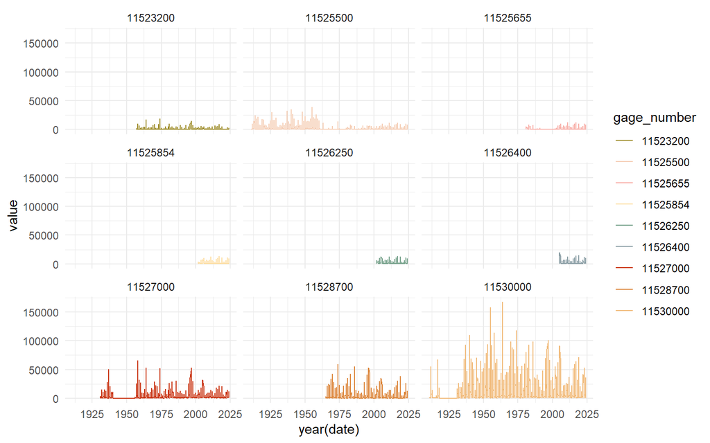

```r
all_trinity_usgs_gages |> ggplot(aes(x = year(date), y = value, color = gage_number)) +
  geom_line() +
  scale_color_manual(values = colors_full) +
  facet_wrap(~gage_number) +
  theme_minimal()
```

### Date range summary

```
#> Rows: 9
#> Columns: 4
#> $ gage_number  <chr> "11523200", "11525500", "11525655", "11525854", "11526250…
#> $ min_date     <date> 1957-10-01, 1911-10-01, 1981-04-28, 2002-10-01, 2002-10-…
#> $ max_date     <date> 2024-10-06, 2024-10-06, 2024-10-06, 2024-10-06, 2024-10-…
#> $ record_count <int> 24477, 41280, 11849, 8042, 8040, 7132, 28130, 21505, 35434
```

## Scott

- 11519500 SCOTT R NR FORT JONES CA

```r
scott <- dataRetrieval::readNWISdv(11519500, "00060") |>
  select(date = Date, value =  X_00060_00003) |>  # rename to value
  as_tibble() |>
  mutate(stream = "scott river",
         gage_agency = "USGS",
         gage_number = "11519500",
         parameter = "flow",
         statistic = "mean", # if query returns instantaneous data then report a min, mean, and max
         latitude = dataRetrieval::readNWISsite("11519500")$dec_lat_va, # directly add lat
         longitude = dataRetrieval::readNWISsite("11519500")$dec_long_va # directly add lon
         )
```

## Shasta

- Shasta R NR Montague CA - 11517000
- Shasta R NR Yreka CA - 11517500

```r
shasta_mont <- dataRetrieval::readNWISdv(11517000, "00060") |>
  select(date = Date, value =  X_00060_00003) |>  # rename to value
  as_tibble() |>
  mutate(stream = "shasta river",
         gage_agency = "USGS",
         gage_number = "11517000",
         parameter = "flow",
         statistic = "mean", # if query returns instantaneous data then report a min, mean, and max
         latitude = dataRetrieval::readNWISsite("11517000")$dec_lat_va, # directly add lat
         longitude = dataRetrieval::readNWISsite("11517000")$dec_long_va # directly add lon
         )

shasta_yreka <- dataRetrieval::readNWISdv(11517500, "00060") |>
  select(date = Date, value =  X_00060_00003) |>  # rename to value
  as_tibble() |>
  mutate(stream = "shasta river",
         gage_agency = "USGS",
         gage_number = "11517500",
         parameter = "flow",
         statistic = "mean", # if query returns instantaneous data then report a min, mean, and max
         latitude = dataRetrieval::readNWISsite("11517500")$dec_lat_va, # directly add lat
         longitude = dataRetrieval::readNWISsite("11517500")$dec_long_va # directly add lon
         )

all_usgs_shasta <- bind_rows(shasta_mont, shasta_yreka) |>
  glimpse()
```

```
#> Rows: 46,780
#> Columns: 9
#> $ date        <date> 1911-10-01, 1911-10-02, 1911-10-03, 1911-10-04, 1911-10-0…
#> $ value       <dbl> 96, 112, 112, 112, 112, 112, 112, 112, 147, 167, 147, 147,…
#> $ stream      <chr> "shasta river", "shasta river", "shasta river", "shasta ri…
#> $ gage_agency <chr> "USGS", "USGS", "USGS", "USGS", "USGS", "USGS", "USGS", "U…
#> $ gage_number <chr> "11517000", "11517000", "11517000", "11517000", "11517000"…
#> $ parameter   <chr> "flow", "flow", "flow", "flow", "flow", "flow", "flow", "f…
#> $ statistic   <chr> "mean", "mean", "mean", "mean", "mean", "mean", "mean", "m…
#> $ latitude    <dbl> 41.70903, 41.70903, 41.70903, 41.70903, 41.70903, 41.70903…
#> $ longitude   <dbl> -122.5381, -122.5381, -122.5381, -122.5381, -122.5381, -12…
```

### Map Plot Shasta USGS

```r
shasta_usgs_dates <- all_usgs_shasta |>
  group_by(gage_number) |>
  summarise(min_date = min(date), max_date = max(date))

# Add the date information to the unique gages
unique_gage_shasta<- all_usgs_shasta |>
  distinct(gage_number, latitude, longitude, .keep_all = TRUE) |>
  left_join(shasta_usgs_dates, by = "gage_number")

unique_gage_shas <- unique_gage_shasta |>
  st_as_sf(coords = c("longitude", "latitude"), crs = 4326)

leaflet(unique_gage_shas) |>
  addTiles() |>
    addCircleMarkers(
    popup = ~paste0("Stream name: ", stream, "<br>Gage Number: ", gage_number, "<br>Max Date: ", max_date, "<br>Min Date: ", min_date)
  )
```

[interactive chart not shown]

### Date coverage plot

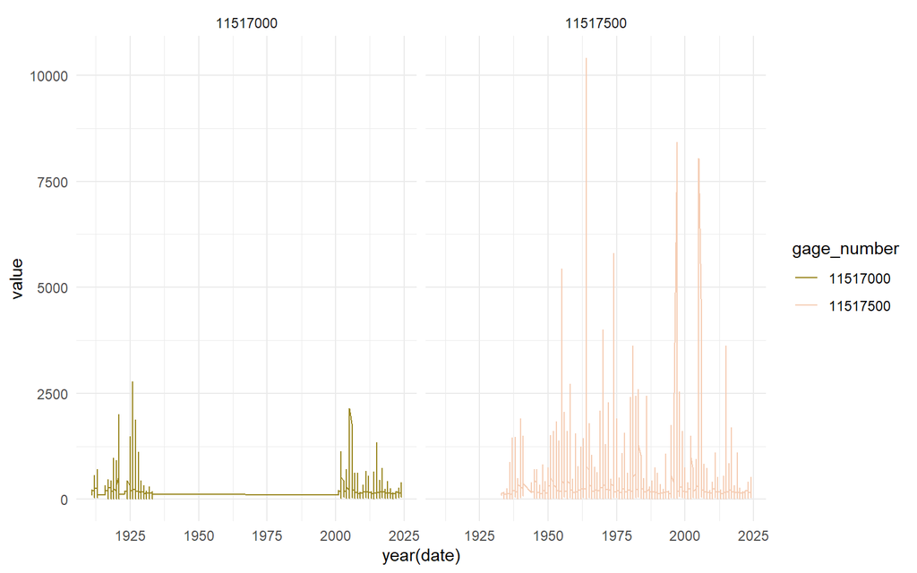

```r
all_usgs_shasta |> ggplot(aes(x = year(date), y = value, color = gage_number)) +
  geom_line() +
  scale_color_manual(values = colors_full) +
  facet_wrap(~gage_number) +
  theme_minimal()
```

### Date range summary

```
#> Rows: 2
#> Columns: 4
#> $ gage_number  <chr> "11517000", "11517500"
#> $ min_date     <date> 1911-10-01, 1933-10-01
#> $ max_date     <date> 2024-10-06, 2024-10-06
#> $ record_count <int> 14614, 32166
```

## Salmon

- 11522500 SALMON R A SOMES BAR CA

```r
salmon_usgs_gage <- dataRetrieval::readNWISdv(11522500, "00060") |>
  select(date = Date, value =  X_00060_00003) |>  # rename to value
  as_tibble() |>
  mutate(stream = "shasta river",
         gage_agency = "USGS",
         gage_number = "11522500",
         parameter = "flow",
         statistic = "mean", # if query returns instantaneous data then report a min, mean, and max
         latitude = dataRetrieval::readNWISsite("11522500")$dec_lat_va, # directly add lat
         longitude = dataRetrieval::readNWISsite("11522500")$dec_long_va # directly add lon
         )
```

### Map Plot Salmon USGS

```r
salmon_gage_dates <- salmon_usgs_gage |>
  group_by(gage_number) |>
  summarise(min_date = min(date), max_date = max(date))

unique_gage_data_salmon <- salmon_usgs_gage |>
  distinct(gage_number, latitude, longitude, .keep_all = TRUE) |>
  left_join(salmon_gage_dates, by = "gage_number")

unique_gage_data_salmon <- unique_gage_data_salmon |>
  st_as_sf(coords = c("longitude", "latitude"), crs = 4326)

leaflet(unique_gage_data_salmon) |>
  addTiles() |>
  addCircleMarkers(popup = ~paste0("Stream name: ", stream, "<br>Gage Number: ", gage_number, "<br>Max Date: ", max_date, "<br>Min Date: ", min_date))
```

[interactive chart not shown]

### Date coverage plot

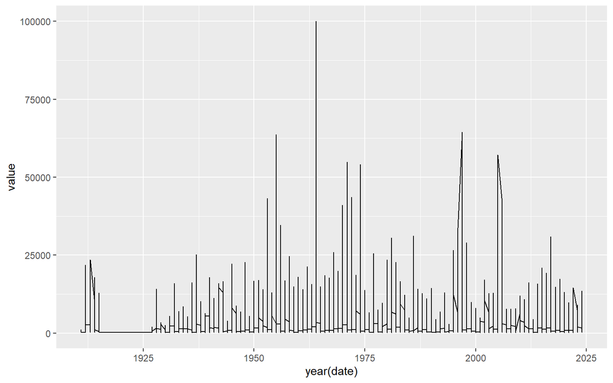

```r
salmon_usgs_gage |> ggplot(aes(x = year(date), y = value)) +
  geom_line() +
  scale_color_manual(values = colors_full)
```

```r
  theme_minimal()
```

[output not shown]

[output cut: 333 more lines]

[output not shown]

### Date range summary

```
#> Rows: 1
#> Columns: 4
#> $ gage_number  <chr> "11522500"
#> $ min_date     <date> 1911-10-01
#> $ max_date     <date> 2024-10-06
#> $ record_count <int> 36896
```

## Sprague

Sprague River Near Chiloquin, OR - 11501000

```r
sprague_usgs_gage <- dataRetrieval::readNWISdv(11501000, "00060") |>
  select(date = Date, value =  X_00060_00003) |>  # rename to value
  as_tibble() |>
  mutate(stream = "sprague river",
         gage_agency = "USGS",
         gage_number = "11501000",
         parameter = "flow",
         statistic = "mean", # if query returns instantaneous data then report a min, mean, and max
         latitude = dataRetrieval::readNWISsite("11501000")$dec_lat_va, # directly add lat
         longitude = dataRetrieval::readNWISsite("11501000")$dec_long_va # directly add lon
         )
```

### Map plot Sprague

```r
sprague_gage_dates <- sprague_usgs_gage |>
  group_by(gage_number) |>
  summarise(min_date = min(date), max_date = max(date))

unique_gage_data_sprague <- sprague_usgs_gage |>
  distinct(gage_number, latitude, longitude, .keep_all = TRUE) |>
  left_join(salmon_gage_dates, by = "gage_number")

unique_gage_data_sprague <- unique_gage_data_sprague |>
  st_as_sf(coords = c("longitude", "latitude"), crs = 4326)

leaflet(unique_gage_data_sprague) |>
  addTiles() |>
  addCircleMarkers(popup = ~paste0("Stream name: ", stream, "<br>Gage Number: ", gage_number, "<br>Max Date: ", max_date, "<br>Min Date: ", min_date))
```

[interactive chart not shown]

### Date coverage plot

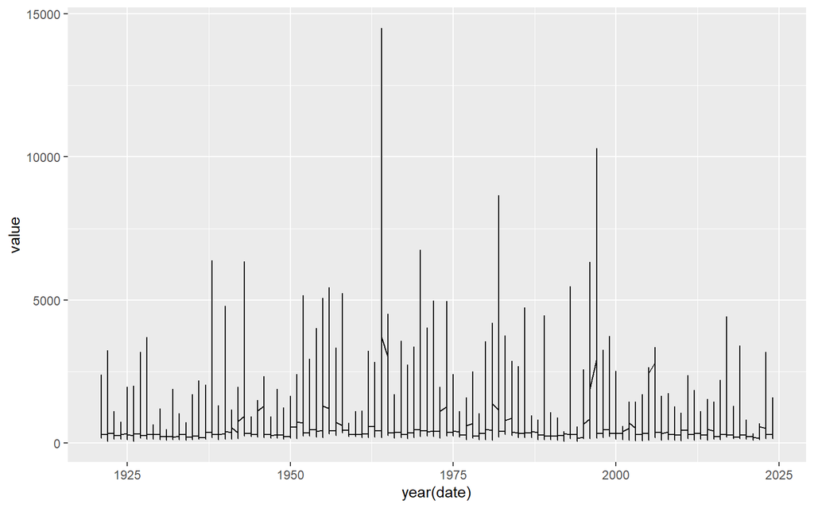

```r
sprague_usgs_gage |> ggplot(aes(x = year(date), y = value)) +
  geom_line() +
  scale_color_manual(values = colors_full)
```

```r
  theme_minimal()
```

[output not shown]

[output cut: 333 more lines]

[output not shown]

### Date range summary

```
#> Rows: 1
#> Columns: 4
#> $ gage_number  <chr> "11501000"
#> $ min_date     <date> 1921-03-01
#> $ max_date     <date> 2024-10-06
#> $ record_count <int> 37841
```

## Indian Creek

List of USGS gages in Klamath watershed:

- Indian C NR Douglas City CA - 11525670
- Indian C NR Happy Camp CA - 11521500

```r
indian_usgs_doug <- dataRetrieval::readNWISdv(11525670, "00060") |>
  select(date = Date, value =  X_00060_00003) |>  # rename to value
  as_tibble() |>
  mutate(stream = "indian creek",
         gage_agency = "USGS",
         gage_number = "11525670",
         parameter = "flow",
         statistic = "mean", # if query returns instantaneous data then report a min, mean, and max
         latitude = dataRetrieval::readNWISsite("11525670")$dec_lat_va, # directly add lat
         longitude = dataRetrieval::readNWISsite("11525670")$dec_long_va # directly add lon
         )
indian_usgs_happy <- dataRetrieval::readNWISdv(11521500, "00060") |>
  select(date = Date, value =  X_00060_00003) |>  # rename to value
  as_tibble() |>
  mutate(stream = "indian creek",
         gage_agency = "USGS",
         gage_number = "11521500",
         parameter = "flow",
         statistic = "mean", # if query returns instantaneous data then report a min, mean, and max
         latitude = dataRetrieval::readNWISsite("11521500")$dec_lat_va, # directly add lat
         longitude = dataRetrieval::readNWISsite("11521500")$dec_long_va # directly add lon
         )

all_indian_usgs_gages <- bind_rows(indian_usgs_doug, indian_usgs_happy) |>
  glimpse()
```

```
#> Rows: 31,894
#> Columns: 9
#> $ date        <date> 2004-10-01, 2004-10-02, 2004-10-03, 2004-10-04, 2004-10-0…
#> $ value       <dbl> 2.74, 2.74, 2.82, 2.81, 2.82, 2.83, 2.88, 2.98, 3.40, 3.40…
#> $ stream      <chr> "indian creek", "indian creek", "indian creek", "indian cr…
#> $ gage_agency <chr> "USGS", "USGS", "USGS", "USGS", "USGS", "USGS", "USGS", "U…
#> $ gage_number <chr> "11525670", "11525670", "11525670", "11525670", "11525670"…
#> $ parameter   <chr> "flow", "flow", "flow", "flow", "flow", "flow", "flow", "f…
#> $ statistic   <chr> "mean", "mean", "mean", "mean", "mean", "mean", "mean", "m…
#> $ latitude    <dbl> 40.65181, 40.65181, 40.65181, 40.65181, 40.65181, 40.65181…
#> $ longitude   <dbl> -122.9145, -122.9145, -122.9145, -122.9145, -122.9145, -12…
```

```r
# Filter to keep only one unique gage per location
indian_gage_dates <- all_indian_usgs_gages |>
  group_by(gage_number) |>
  summarise(min_date = min(date), max_date = max(date))

unique_gage_data_indian <- all_indian_usgs_gages |>
  distinct(gage_number, latitude, longitude, .keep_all = TRUE) |>
  left_join(indian_gage_dates, by = "gage_number")

unique_gage_indian <- unique_gage_data_indian |>
  st_as_sf(coords = c("longitude", "latitude"), crs = 4326)

leaflet(unique_gage_indian) |>
  addTiles() |>
  addCircleMarkers(popup = ~paste0("Stream name: ", stream, "<br>Gage Number: ", gage_number, "<br>Max Date: ", max_date, "<br>Min Date: ", min_date))
```

[interactive chart not shown]

### Date coverage

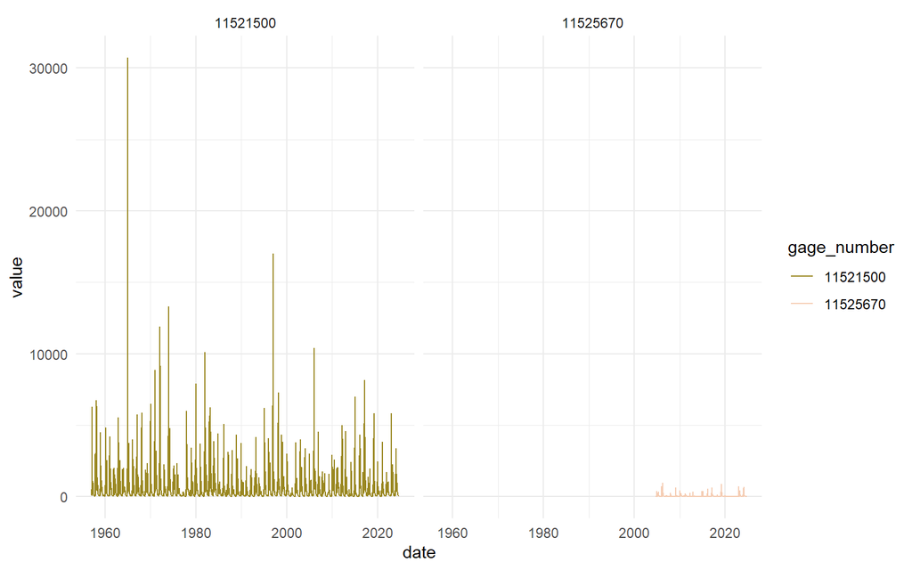

```r
all_indian_usgs_gages |> ggplot(aes(x = date, y = value, color = gage_number)) +
  geom_line() +
  scale_color_manual(values = colors_full) +
  facet_wrap(~gage_number) +
  theme_minimal()
```

## Other streams - Oregon

- Klamath Straits Drain Near Worden, OR - 11509340
- Ady Canal Above Lower Klamath Nwr, Near Worden, OR - 11509250
- North Canal at Highway 97, Near Midland, OR - 11509105
- Link River at Klamath Falls, OR - 11507500
- Williamson River Blw Sprague River NR Chiloquin,or - 11502500
- Crystal Creek Near Rocky Point, OR - 11504270 - NODATA
- Fourmile Canal Near Klamath Agency, OR - 11504260
- Sevenmile Cnl at Dike RD Br, NR Klamath Agency, OR - 11504290

```r
other_usgs_or1 <- dataRetrieval::readNWISdv(11509340, "00060") |>
  select(date = Date, value =  X_00060_00003) |>  # rename to value
  as_tibble() |>
  mutate(stream = "",
         gage_agency = "USGS",
         gage_number = "11509340",
         parameter = "flow",
         statistic = "mean", # if query returns instantaneous data then report a min, mean, and max
         latitude = dataRetrieval::readNWISsite("11509340")$dec_lat_va, # directly add lat
         longitude = dataRetrieval::readNWISsite("11509340")$dec_long_va # directly add lon
         )
other_usgs_or2 <- dataRetrieval::readNWISdv(11509250, "00060") |>
  select(date = Date, value =  X_00060_00003) |>  # rename to value
  as_tibble() |>
  mutate(stream = "",
         gage_agency = "USGS",
         gage_number = "11509250",
         parameter = "flow",
         statistic = "mean", # if query returns instantaneous data then report a min, mean, and max
         latitude = dataRetrieval::readNWISsite("11509250")$dec_lat_va, # directly add lat
         longitude = dataRetrieval::readNWISsite("11509250")$dec_long_va # directly add lon
         )
other_usgs_or3 <- dataRetrieval::readNWISdv(11509105, "00060") |>
  select(date = Date, value =  X_00060_00003) |>  # rename to value
  as_tibble() |>
  mutate(stream = "",
         gage_agency = "USGS",
         gage_number = "11509105",
         parameter = "flow",
         statistic = "mean", # if query returns instantaneous data then report a min, mean, and max
         latitude = dataRetrieval::readNWISsite("11509105")$dec_lat_va, # directly add lat
         longitude = dataRetrieval::readNWISsite("11509105")$dec_long_va # directly add lon
         )
other_usgs_or4 <- dataRetrieval::readNWISdv(11507500, "00060") |>
  select(date = Date, value =  X_00060_00003) |>  # rename to value
  as_tibble() |>
  mutate(stream = "",
         gage_agency = "USGS",
         gage_number = "11507500",
         parameter = "flow",
         statistic = "mean", # if query returns instantaneous data then report a min, mean, and max
         latitude = dataRetrieval::readNWISsite("11507500")$dec_lat_va, # directly add lat
         longitude = dataRetrieval::readNWISsite("11507500")$dec_long_va # directly add lon
         )
other_usgs_or5 <- dataRetrieval::readNWISdv(11502500, "00060") |>
  select(date = Date, value =  X_00060_00003) |>  # rename to value
  as_tibble() |>
  mutate(stream = "",
         gage_agency = "USGS",
         gage_number = "11502500",
         parameter = "flow",
         statistic = "mean", # if query returns instantaneous data then report a min, mean, and max
         latitude = dataRetrieval::readNWISsite("11502500")$dec_lat_va, # directly add lat
         longitude = dataRetrieval::readNWISsite("11502500")$dec_long_va # directly add lon
         )

other_usgs_or6 <- dataRetrieval::readNWISdv(11504260, "00060") |>
  select(date = Date, value =  X_00060_00003) |>  # rename to value
  as_tibble() |>
  mutate(stream = "",
         gage_agency = "USGS",
         gage_number = "11504260",
         parameter = "flow",
         statistic = "mean", # if query returns instantaneous data then report a min, mean, and max
         latitude = dataRetrieval::readNWISsite("11504260")$dec_lat_va, # directly add lat
         longitude = dataRetrieval::readNWISsite("11504260")$dec_long_va # directly add lon
         )
other_usgs_or7 <- dataRetrieval::readNWISdv(11504290, "00060") |>
  select(date = Date, value =  X_00060_00003) |>  # rename to value
  as_tibble() |>
  mutate(stream = "",
         gage_agency = "USGS",
         gage_number = "11504290",
         parameter = "flow",
         statistic = "mean", # if query returns instantaneous data then report a min, mean, and max
         latitude = dataRetrieval::readNWISsite("11504290")$dec_lat_va, # directly add lat
         longitude = dataRetrieval::readNWISsite("11504290")$dec_long_va # directly add lon
         )

all_or_usgs_gages <- bind_rows(other_usgs_or1, other_usgs_or2, other_usgs_or3, other_usgs_or4, other_usgs_or5, other_usgs_or6, other_usgs_or7) |>
  glimpse()
```

```
#> Rows: 79,355
#> Columns: 9
#> $ date        <date> 2011-10-31, 2011-11-01, 2011-11-02, 2011-11-03, 2011-11-0…
#> $ value       <dbl> 20.60, 1.33, 31.50, 38.50, 4.37, 36.00, 28.00, 29.90, 24.6…
#> $ stream      <chr> "", "", "", "", "", "", "", "", "", "", "", "", "", "", ""…
#> $ gage_agency <chr> "USGS", "USGS", "USGS", "USGS", "USGS", "USGS", "USGS", "U…
#> $ gage_number <chr> "11509340", "11509340", "11509340", "11509340", "11509340"…
#> $ parameter   <chr> "flow", "flow", "flow", "flow", "flow", "flow", "flow", "f…
#> $ statistic   <chr> "mean", "mean", "mean", "mean", "mean", "mean", "mean", "m…
#> $ latitude    <dbl> 42.08095, 42.08095, 42.08095, 42.08095, 42.08095, 42.08095…
#> $ longitude   <dbl> -121.8483, -121.8483, -121.8483, -121.8483, -121.8483, -12…
```

```r
# Filter to keep only one unique gage per location

gage_dates_or <- all_or_usgs_gages |>
  group_by(gage_number) |>
  summarise(min_date = min(date), max_date = max(date))

# Add the date information to the unique gages
unique_gage_or <- all_or_usgs_gages |>
  distinct(gage_number, latitude, longitude, .keep_all = TRUE) |>
  left_join(gage_dates_or, by = "gage_number")

unique_gage_or <- unique_gage_or |>
  st_as_sf(coords = c("longitude", "latitude"), crs = 4326)

leaflet(unique_gage_or) |>
  addTiles() |>
    addCircleMarkers(
    popup = ~paste0("Stream name: ", stream, "<br>Gage Number: ", gage_number, "<br>Max Date: ", max_date, "<br>Min Date: ", min_date)
  )
```

[interactive chart not shown]

### Date coverage

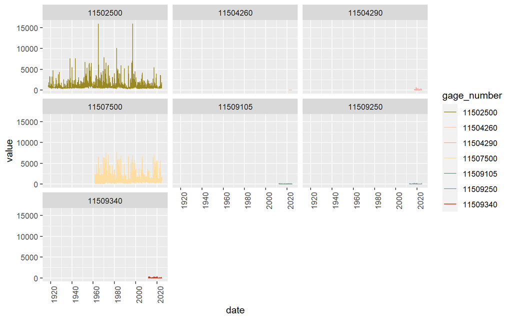

```r
all_or_usgs_gages |> ggplot(aes(x = date, y = value, color = gage_number)) +
  geom_line() +
  scale_color_manual(values = colors_full) +
  facet_wrap(~gage_number) +
  theme(axis.text.x = element_text(angle = 90, hjust = 1))
```

### Date range summary

```
#> Rows: 7
#> Columns: 4
#> $ gage_number  <chr> "11502500", "11504260", "11504290", "11507500", "11509105…
#> $ min_date     <date> 1917-10-01, 2021-08-05, 2017-05-04, 1961-10-01, 2012-02-…
#> $ max_date     <date> 2024-10-06, 2024-10-06, 2024-10-06, 2024-10-06, 2024-10-…
#> $ record_count <int> 38754, 1154, 2713, 23017, 4604, 4388, 4725
```